# Tarea 10

Martin Santamaria

13/2/2020

## Carga de datos

```r
library(MASS)
data = MASS::birthwt
```

## Punto 1

```r
str(data)
```

```
## 'data.frame':    189 obs. of  10 variables:
##  $ low  : int  0 0 0 0 0 0 0 0 0 0 ...
##  $ age  : int  19 33 20 21 18 21 22 17 29 26 ...
##  $ lwt  : int  182 155 105 108 107 124 118 103 123 113 ...
##  $ race : int  2 3 1 1 1 3 1 3 1 1 ...
##  $ smoke: int  0 0 1 1 1 0 0 0 1 1 ...
##  $ ptl  : int  0 0 0 0 0 0 0 0 0 0 ...
##  $ ht   : int  0 0 0 0 0 0 0 0 0 0 ...
##  $ ui   : int  1 0 0 1 1 0 0 0 0 0 ...
##  $ ftv  : int  0 3 1 2 0 0 1 1 1 0 ...
##  $ bwt  : int  2523 2551 2557 2594 2600 2622 2637 2637 2663 2665 ...
```

```r
head(data, 5)
```

```
##    low age lwt race smoke ptl ht ui ftv  bwt
## 85   0  19 182    2     0   0  0  1   0 2523
## 86   0  33 155    3     0   0  0  0   3 2551
## 87   0  20 105    1     1   0  0  0   1 2557
## 88   0  21 108    1     1   0  0  1   2 2594
## 89   0  18 107    1     1   0  0  1   0 2600
```

```r
#?MASS::birthwt
```

## Punto 2

```r
levels(factor(data$race))
```

```
## [1] "1" "2" "3"
```

```r
levels(factor(data$low))
```

```
## [1] "0" "1"
```

```r
t <- table(data$race, data$low, dnn = c("Raza", "Peso_Menor_2.5_kg"))
t
```

```
##     Peso_Menor_2.5_kg
## Raza  0  1
##    1 73 23
##    2 15 11
##    3 42 25
```

```r
dimnames(t) <- list(
                    Raza = c("Blanca", "Negra", "Otra"),
                    Peso_Menor_2.5_kg = c("No", "Si")
                   )
t
```

```
##         Peso_Menor_2.5_kg
## Raza     No Si
##   Blanca 73 23
##   Negra  15 11
##   Otra   42 25
```

```r
#round(prop.table(t, margin = 1), 3)
round(prop.table(t, margin = 2), 3)
```

```
##         Peso_Menor_2.5_kg
## Raza        No    Si
##   Blanca 0.562 0.390
##   Negra  0.115 0.186
##   Otra   0.323 0.424
```

De los resultados de la tabla anterior, se observa que en las razas Negra y Otra predominan los nacidos por debajo de los 2.5 kg en comparación con la raza Blanca.

## Punto 3

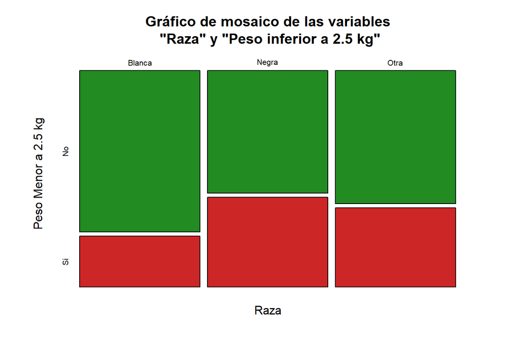

```r
plot(prop.table(t, margin = 1),
     main = "Gráfico de mosaico de las variables\n \"Raza\" y \"Peso inferior a 2.5 kg\"",
     col = c("forestgreen", "firebrick3"),
     ylab = "Peso Menor a 2.5 kg")
```

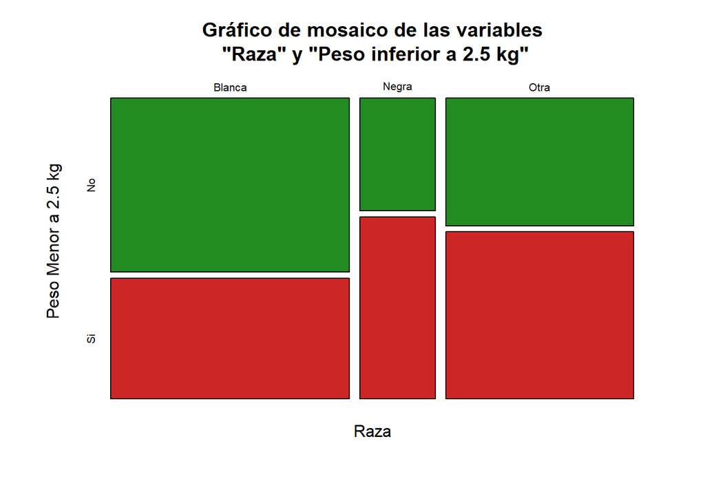

```r
plot(prop.table(t, margin = 2),
     main = "Gráfico de mosaico de las variables\n \"Raza\" y \"Peso inferior a 2.5 kg\"",
     col = c("forestgreen", "firebrick3"),
     ylab = "Peso Menor a 2.5 kg")
```

## Punto 4

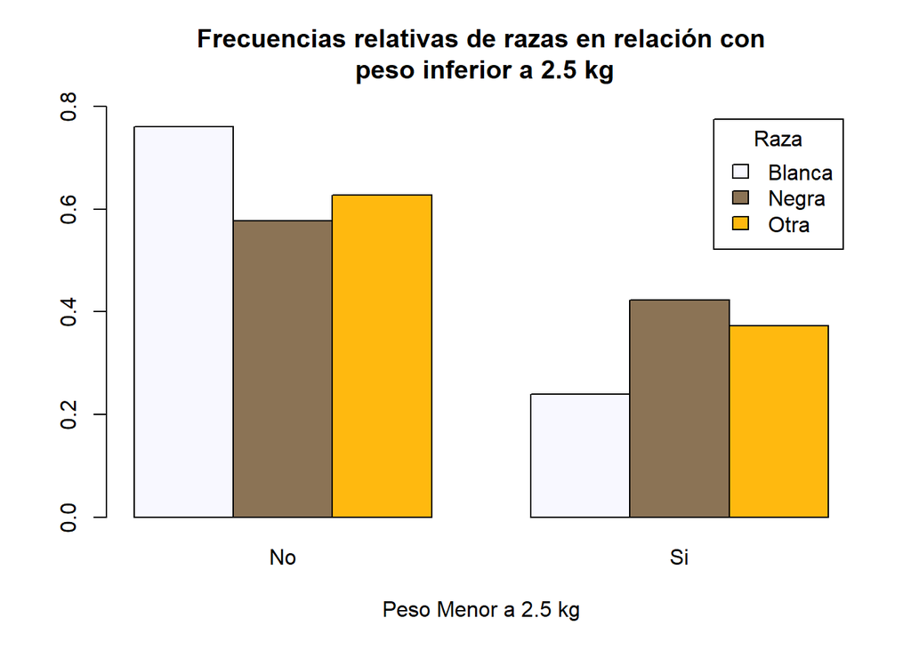

```r
barplot(prop.table(t, margin = 1),
        beside = TRUE,
        legend.text = TRUE,
        args.legend = list(title = "Raza"),
        col = c("ghostwhite", "burlywood4", "darkgoldenrod1"),
        main = "Frecuencias relativas de razas en relación con\n peso inferior a 2.5 kg",
        ylim = c(0, 0.8),
        xlab = "Peso Menor a 2.5 kg")
```

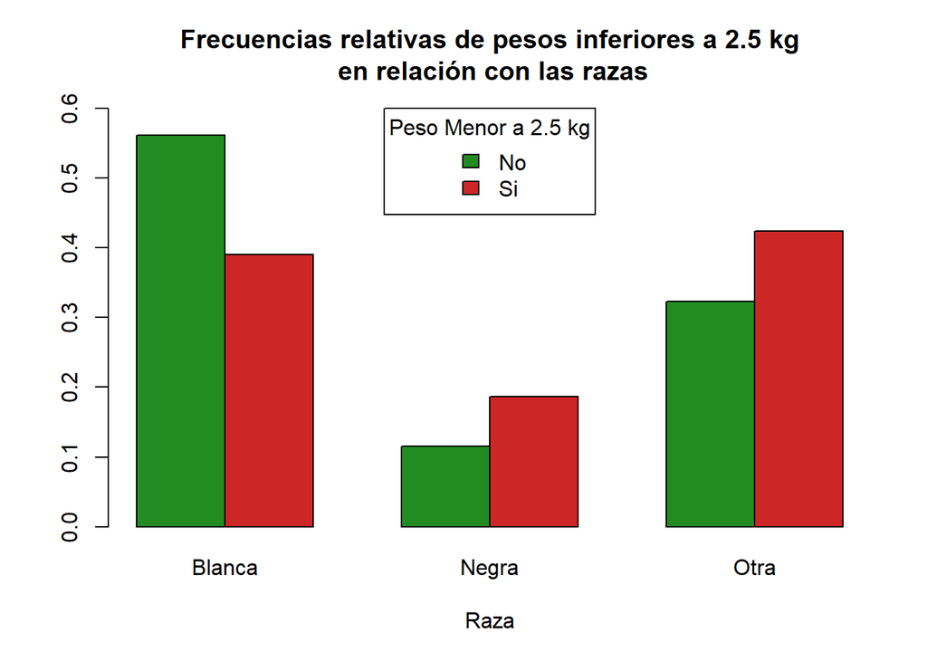

```r
barplot(t(prop.table(t, margin = 2)),
        beside = TRUE,
        legend.text = TRUE,
        args.legend = list(
                           title = "Peso Menor a 2.5 kg",
                           x = "top"
                          ),
        col = c("forestgreen", "firebrick3"),
        main = "Frecuencias relativas de pesos inferiores a 2.5 kg\n en relación con las razas",
        ylim = c(0, 0.6),
        xlab = "Raza")
```

## Punto 5

De los resultados plasmados en los gráficos, se observa que en las razas Negra y Otra predominan los nacidos por debajo de los 2.5 kg en comparación con la raza Blanca.

## Punto 6

### Par Fumadora - Peso Inferior 2.5 kg

```r
levels(factor(data$smoke))
```

```
## [1] "0" "1"
```

```r
tf <- table(data$smoke, data$low, dnn = c("Fuma", "Peso_Menor_2.5_kg"))
tf
```

```
##     Peso_Menor_2.5_kg
## Fuma  0  1
##    0 86 29
##    1 44 30
```

```r
dimnames(tf) <- list(
                     Fuma = c("No", "Si"),
                     Peso_Menor_2.5_kg = c("No", "Si")
                    )
tf
```

```
##     Peso_Menor_2.5_kg
## Fuma No Si
##   No 86 29
##   Si 44 30
```

```r
round(prop.table(tf, margin = 2), 3)
```

```
##     Peso_Menor_2.5_kg
## Fuma    No    Si
##   No 0.662 0.492
##   Si 0.338 0.508
```

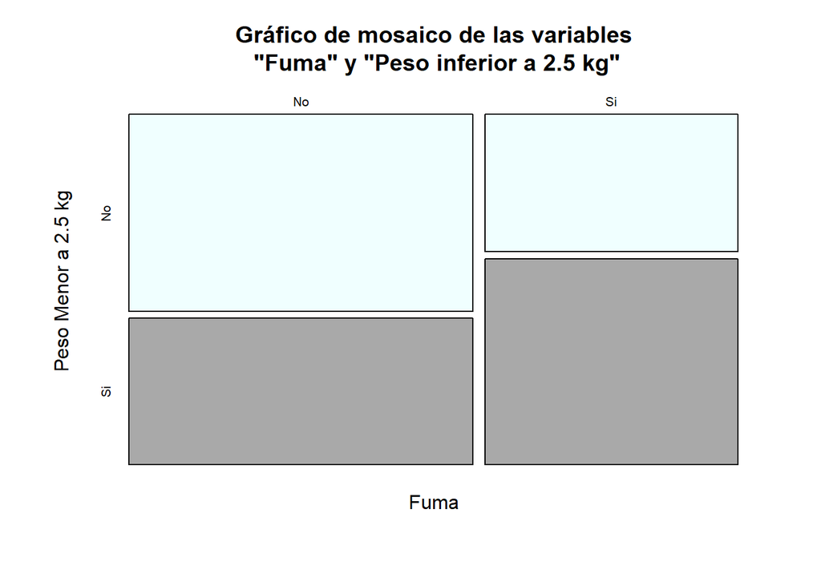

```r
plot(prop.table(tf, margin = 2),
     main = "Gráfico de mosaico de las variables\n \"Fuma\" y \"Peso inferior a 2.5 kg\"",
     col = c("azure", "darkgrey"),
     ylab = "Peso Menor a 2.5 kg")
```

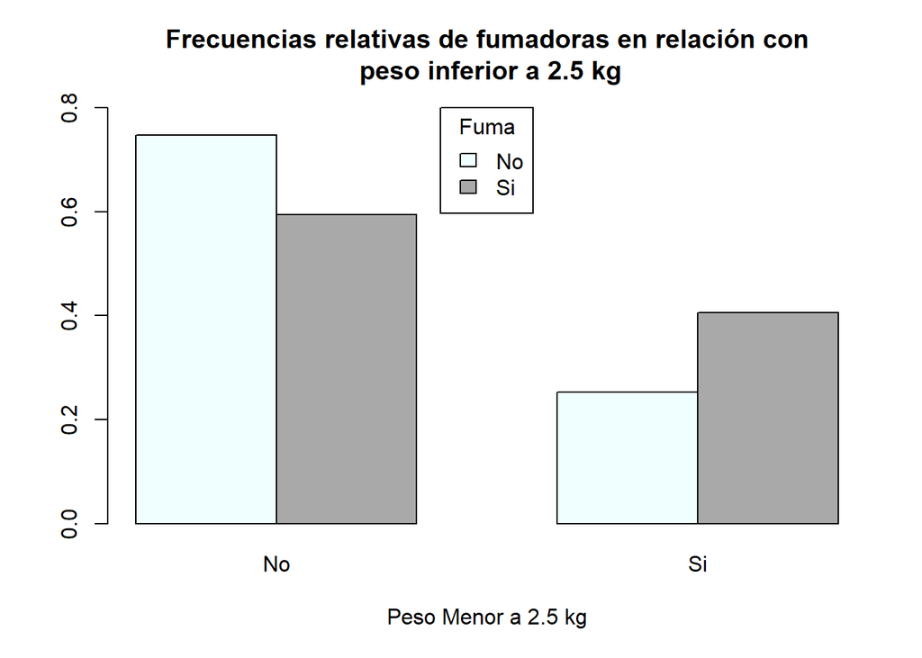

```r
barplot(prop.table(tf, margin = 1),
        beside = TRUE,
        legend.text = TRUE,
        args.legend = list(
                           title = "Fuma",
                           x = "top"
                          ),
        col = c("azure", "darkgrey"),
        main = "Frecuencias relativas de fumadoras en relación con\n peso inferior a 2.5 kg",
        ylim = c(0, 0.8),
        xlab = "Peso Menor a 2.5 kg")
```

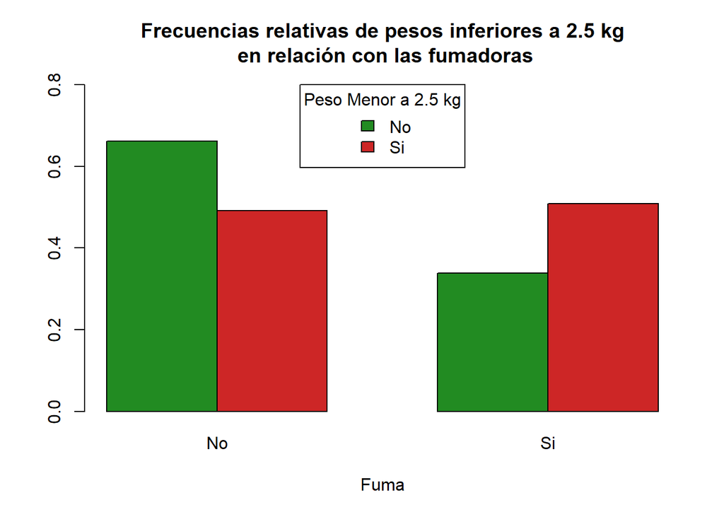

```r
barplot(t(prop.table(tf, margin = 2)),
        beside = TRUE,
        legend.text = TRUE,
        args.legend = list(
                           title = "Peso Menor a 2.5 kg",
                           x = "top"
                          ),
        col = c("forestgreen", "firebrick3"),
        main = "Frecuencias relativas de pesos inferiores a 2.5 kg\n en relación con las fumadoras",
        ylim = c(0, 0.8),
        xlab = "Fuma")
```

De los resultados plasmados en los gráficos, se observa que en las fumadoras predominan los nacidos por debajo de los 2.5 kg en comparación con las no fumadoras.

### Par Hipertensa - Peso Inferior 2.5 kg

```r
levels(factor(data$ht))
```

```
## [1] "0" "1"
```

```r
th <- table(data$ht, data$low, dnn = c("Hipertensa", "Peso_Menor_2.5_kg"))
th
```

```
##           Peso_Menor_2.5_kg
## Hipertensa   0   1
##          0 125  52
##          1   5   7
```

```r
dimnames(th) <- list(
                     Hipertensa =        c("No", "Si"),
                     Peso_Menor_2.5_kg = c("No", "Si")
                    )
th
```

```
##           Peso_Menor_2.5_kg
## Hipertensa  No  Si
##         No 125  52
##         Si   5   7
```

```r
round(prop.table(th, margin = 2), 3)
```

```
##           Peso_Menor_2.5_kg
## Hipertensa    No    Si
##         No 0.962 0.881
##         Si 0.038 0.119
```

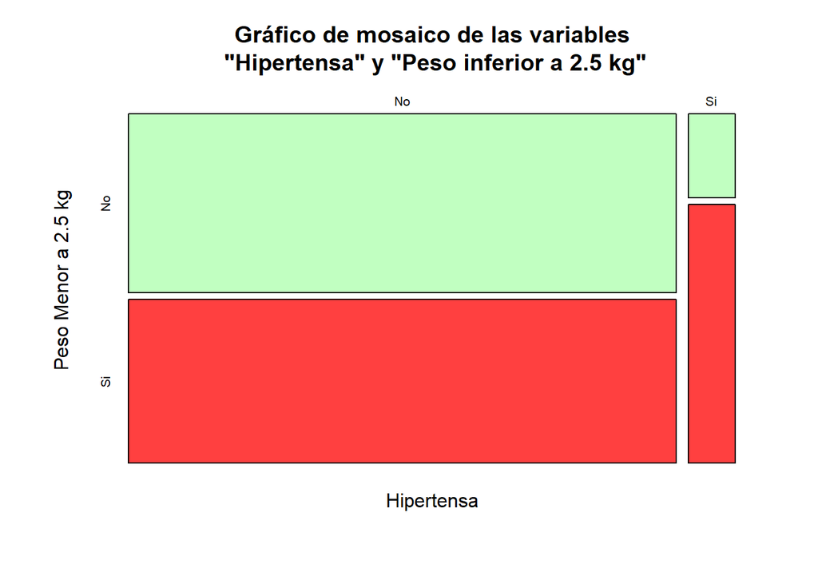

```r
plot(prop.table(th, margin = 2),
     main = "Gráfico de mosaico de las variables\n \"Hipertensa\" y \"Peso inferior a 2.5 kg\"",
     col = c("darkseagreen1", "brown1"),
     ylab = "Peso Menor a 2.5 kg")
```

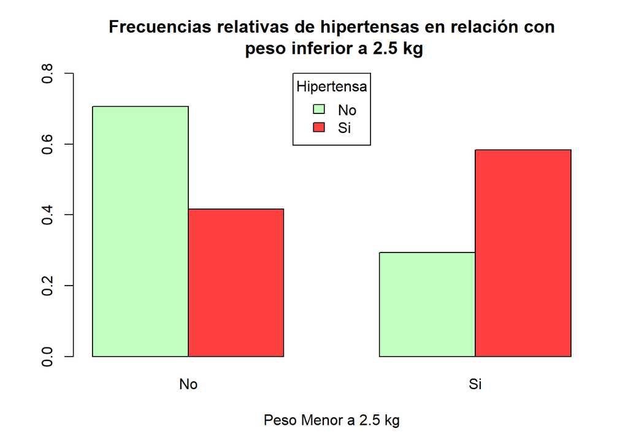

```r
barplot(prop.table(th, margin = 1),
        beside = TRUE,
        legend.text = TRUE,
        args.legend = list(
                           title = "Hipertensa",
                           x = "top"
                          ),
        col = c("darkseagreen1", "brown1"),
        main = "Frecuencias relativas de hipertensas en relación con\n peso inferior a 2.5 kg",
        ylim = c(0, 0.8),
        xlab = "Peso Menor a 2.5 kg")
```

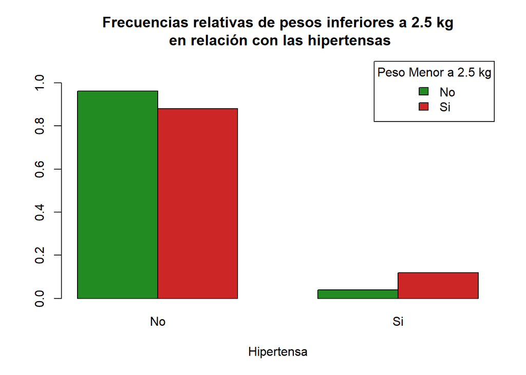

```r
barplot(t(prop.table(th, margin = 2)),
        beside = TRUE,
        legend.text = TRUE,
        args.legend = list(
                           title = "Peso Menor a 2.5 kg",
                           x = "topright"
                          ),
        col = c("forestgreen", "firebrick3"),
        main = "Frecuencias relativas de pesos inferiores a 2.5 kg\n en relación con las hipertensas",
        ylim = c(0, 1.1),
        xlab = "Hipertensa")
```

De los resultados plasmados en los gráficos, se observa que en las hipertensas predominan los nacidos por debajo de los 2.5 kg en comparación con las no hipertensas.

## Punto 7

```r
tt <- table(data$race, data$smoke, data$low, dnn = c("Raza", "Fuma", "Peso_Menor_2.5_kg"))
tt
```

```
## , , Peso_Menor_2.5_kg = 0
##
##     Fuma
## Raza  0  1
##    1 40 33
##    2 11  4
##    3 35  7
##
## , , Peso_Menor_2.5_kg = 1
##
##     Fuma
## Raza  0  1
##    1  4 19
##    2  5  6
##    3 20  5
```

```r
dimnames(tt) <- list(
                     Raza = c("Blanca", "Negra", "Otra"),
                     Fuma = c("No", "Si"),
                     Peso_Menor_2.5_kg = c("No", "Si")
                    )
tt
```

```
## , , Peso_Menor_2.5_kg = No
##
##         Fuma
## Raza     No Si
##   Blanca 40 33
##   Negra  11  4
##   Otra   35  7
##
## , , Peso_Menor_2.5_kg = Si
##
##         Fuma
## Raza     No Si
##   Blanca  4 19
##   Negra   5  6
##   Otra   20  5
```

```r
round(prop.table(tt, margin = c(1,2)), 3)
```

```
## , , Peso_Menor_2.5_kg = No
##
##         Fuma
## Raza        No    Si
##   Blanca 0.909 0.635
##   Negra  0.688 0.400
##   Otra   0.636 0.583
##
## , , Peso_Menor_2.5_kg = Si
##
##         Fuma
## Raza        No    Si
##   Blanca 0.091 0.365
##   Negra  0.312 0.600
##   Otra   0.364 0.417
```

Es interesante notar que la raza Negra y Fumadora tiene un mayor indice de que los bebes nazcan por debajo de los 2.5 kg.

## Punto 8

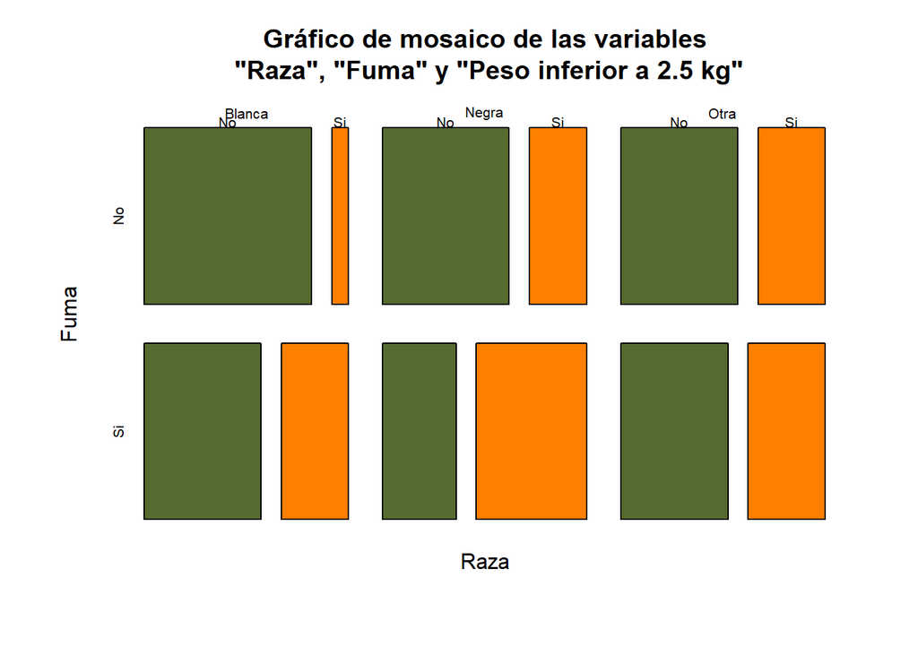

```r
plot(prop.table(tt, margin = c(1,2)),
     main = "Gráfico de mosaico de las variables\n \"Raza\", \"Fuma\" y \"Peso inferior a 2.5 kg\"",
     col = c("darkolivegreen", "darkorange1"))
```

Se puede observar la misma relación en el gráfico de mosaico